# 2020 Q

# MOOS air pressure

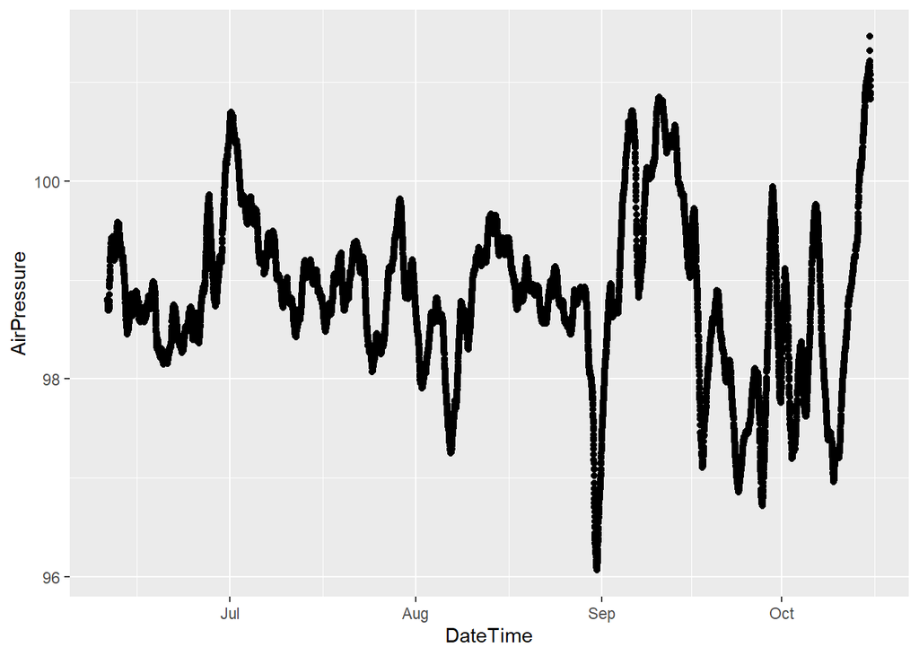

Take difference between air and water pressure. Export PT data to csv in DoD_Discharge->PT_data->2020

Plot difference

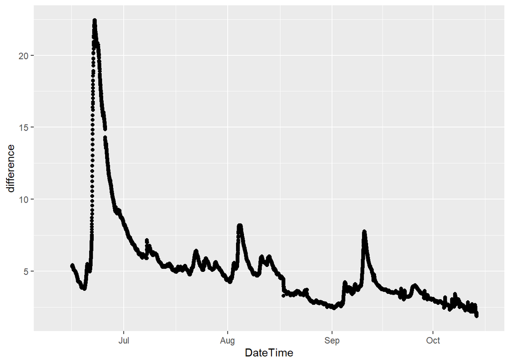

## Raw Rating Curve with MOOS PT2

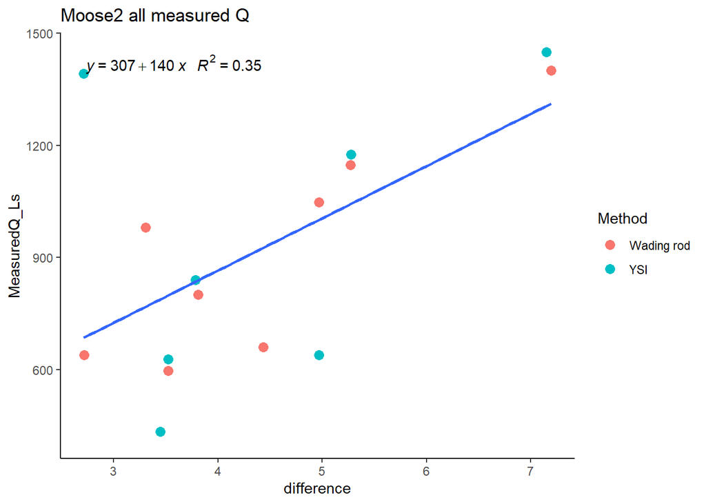

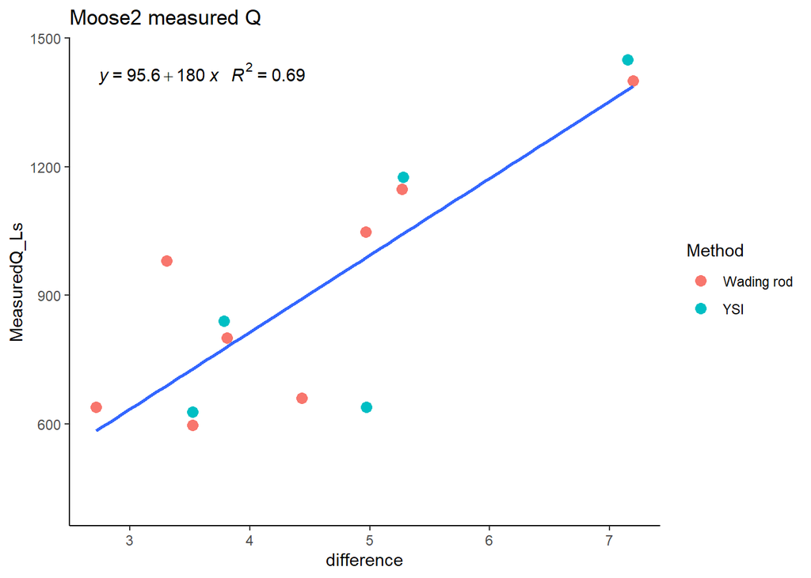

## Final Q for MOOS PT2

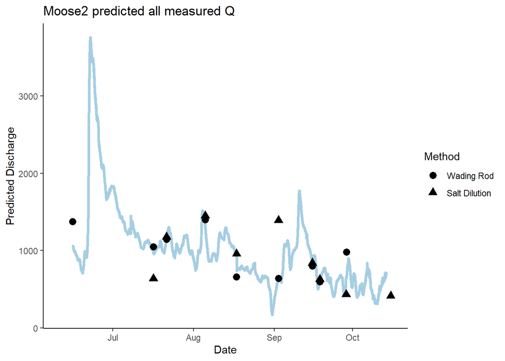

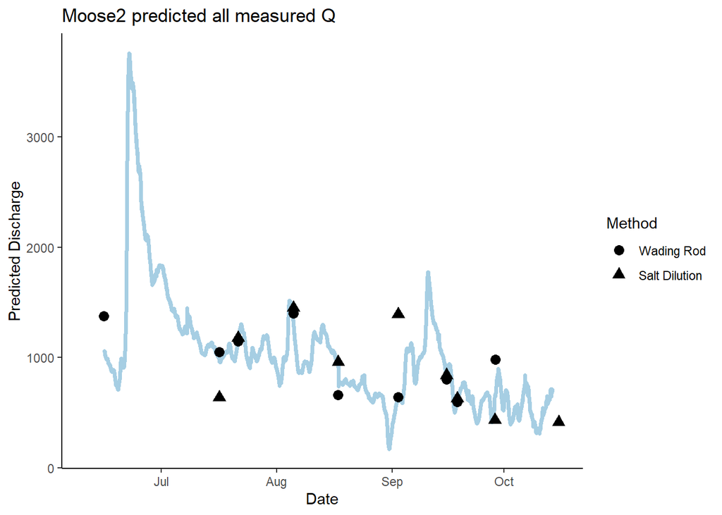

## Export predicted Q to csv in DoD_Discharge->Predicted_Discharge->2020

# Raw air pressure

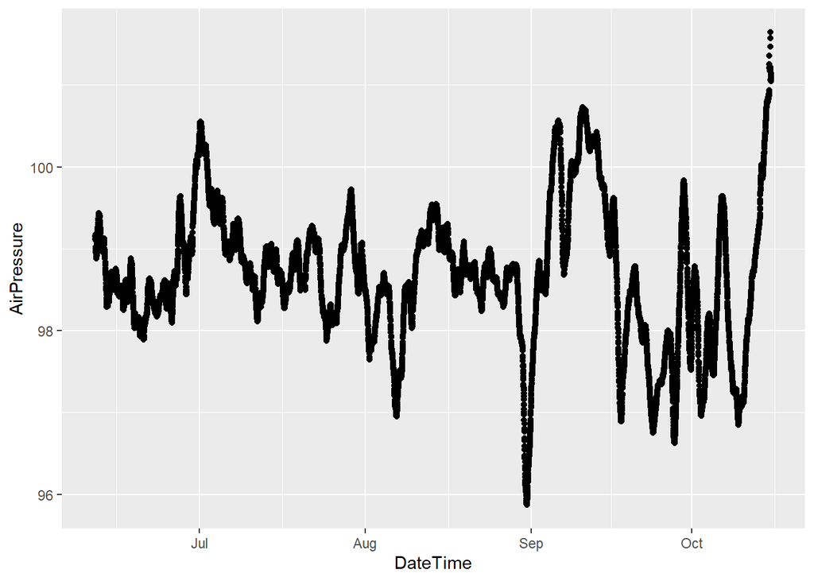

## Raw French PT1

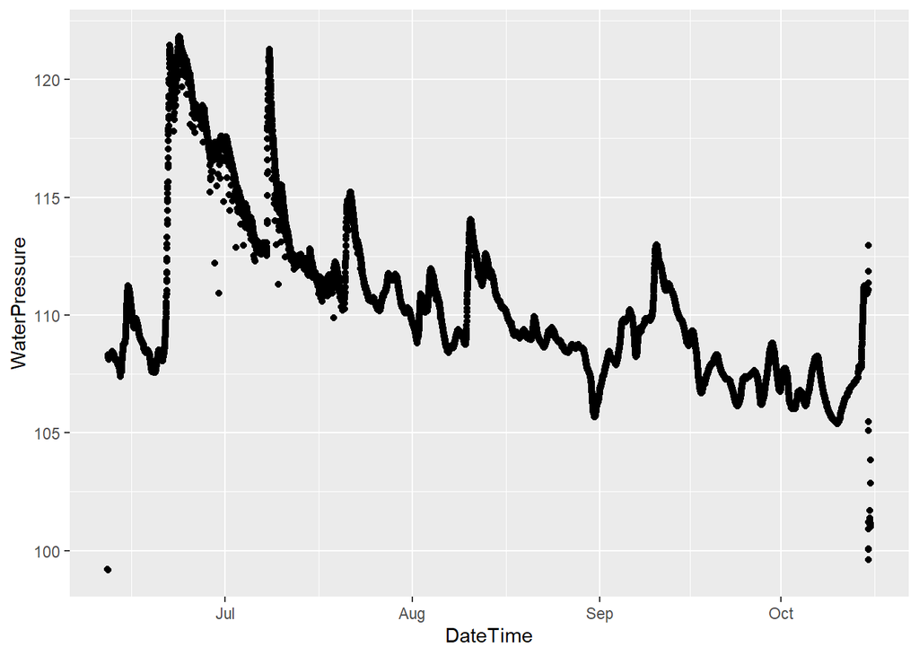

Needs cleaning for out of water points that are associated with install and decommission. Noisy on the falling limb of these storms! Let the cleaning commence!

## French PT1 2.0

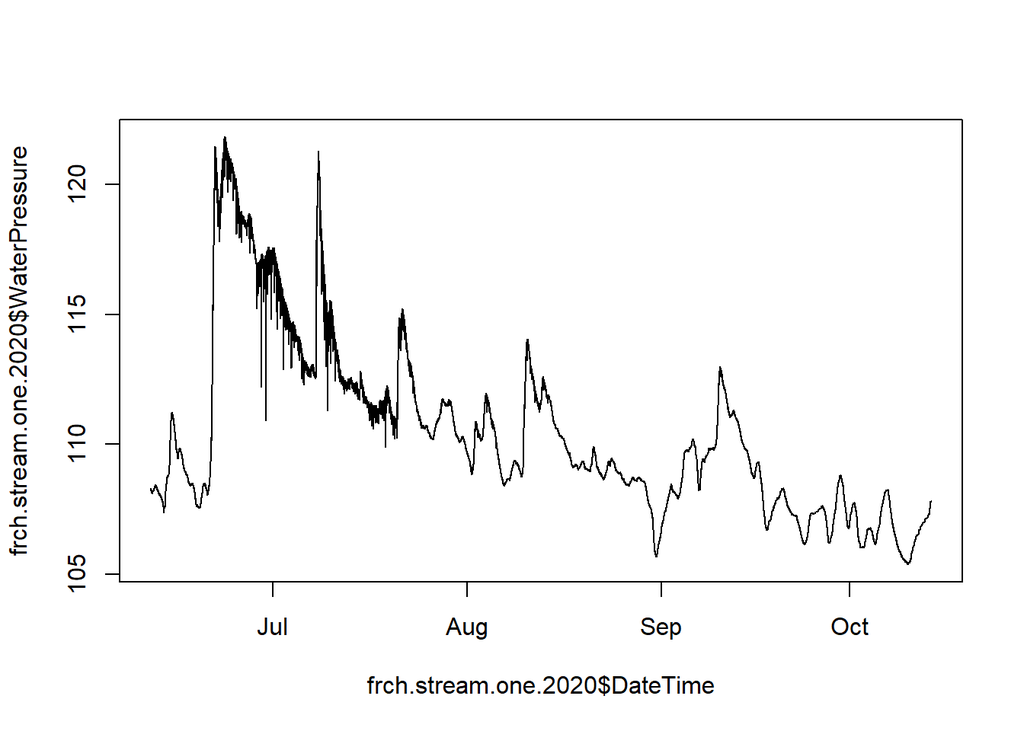

1. Removed points after October 14th (when we took out PTs) and out of water points in the beginning of the dataset
2. Removed noisy points on receding limb of big storm events in the beginning of the dataframe

## Raw French PT2

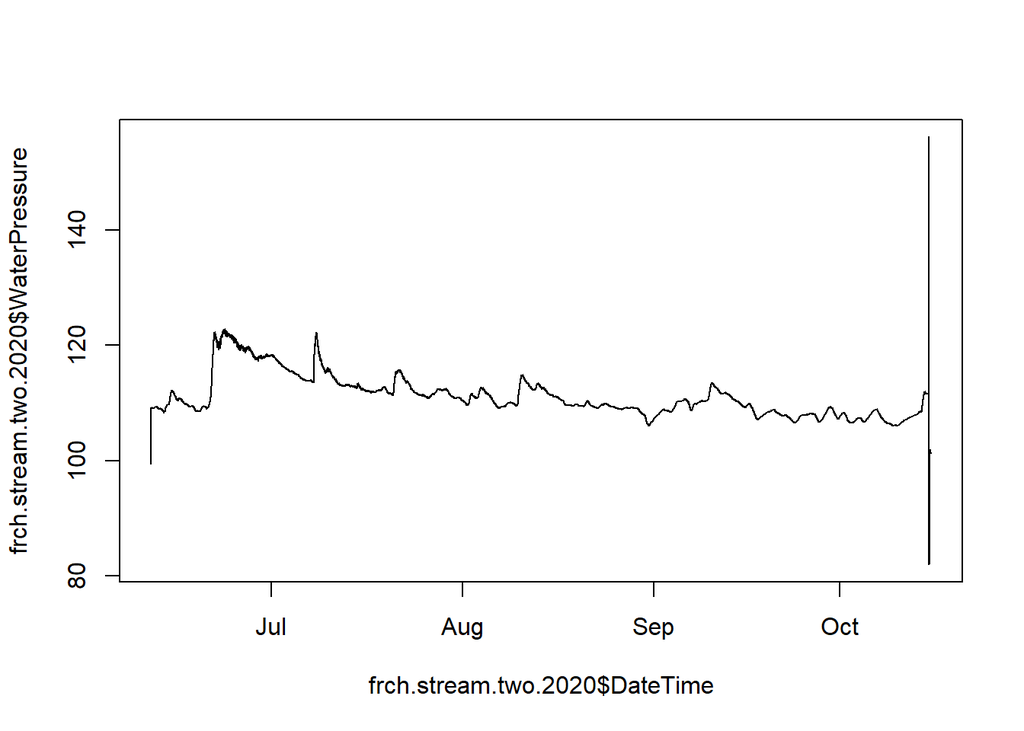

Receding limb of first initial storm is noisy on this one too

## French PT2 2.0

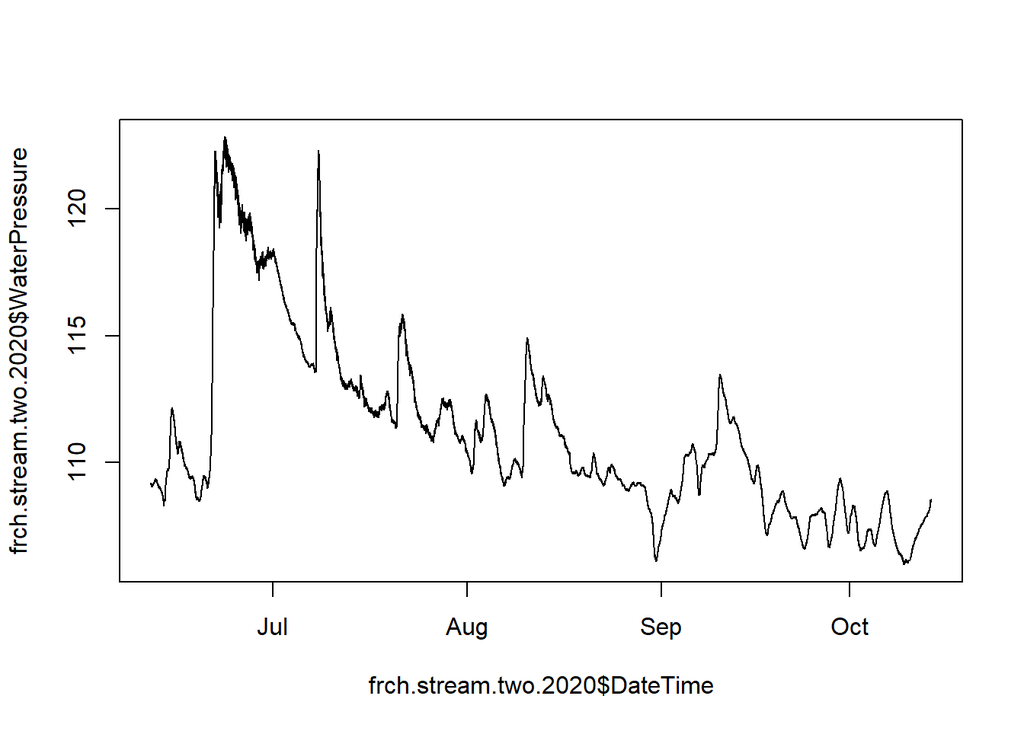

1. removed out of water points from taking out on the 14th of October

PT2 is cleaner than PT1 so lets only use PT2 moving forward.

## Calculate difference between air and water pressure

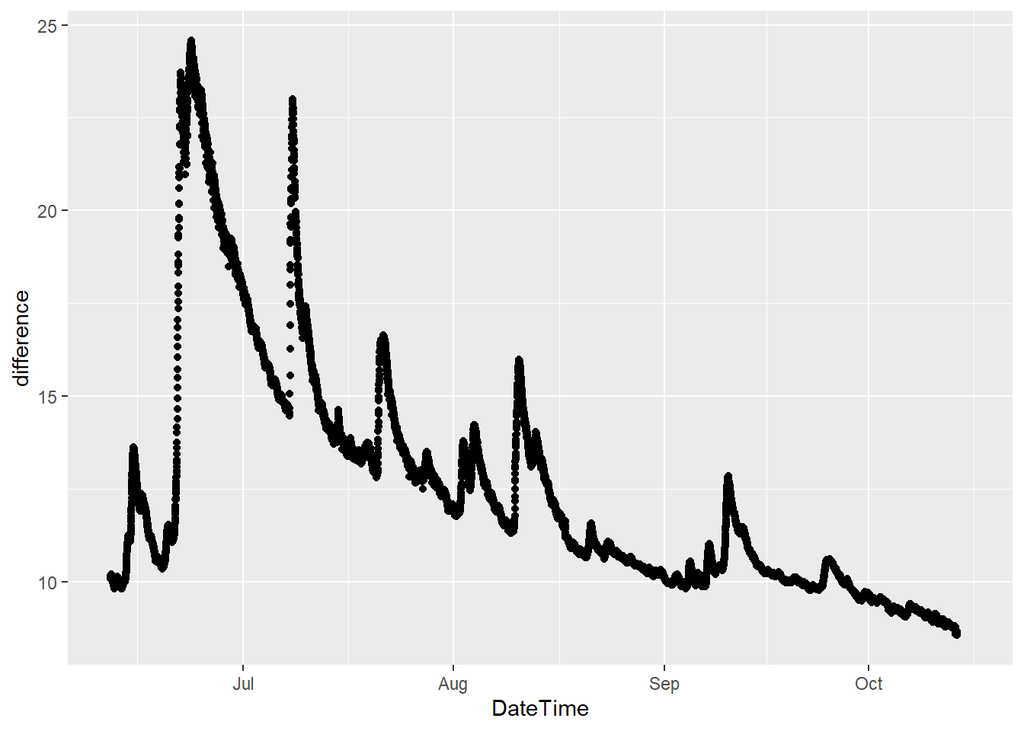

## Export PT data to csv in DoD_Discharge->PT_data->2020

## Raw Rating curve FRCH PT2

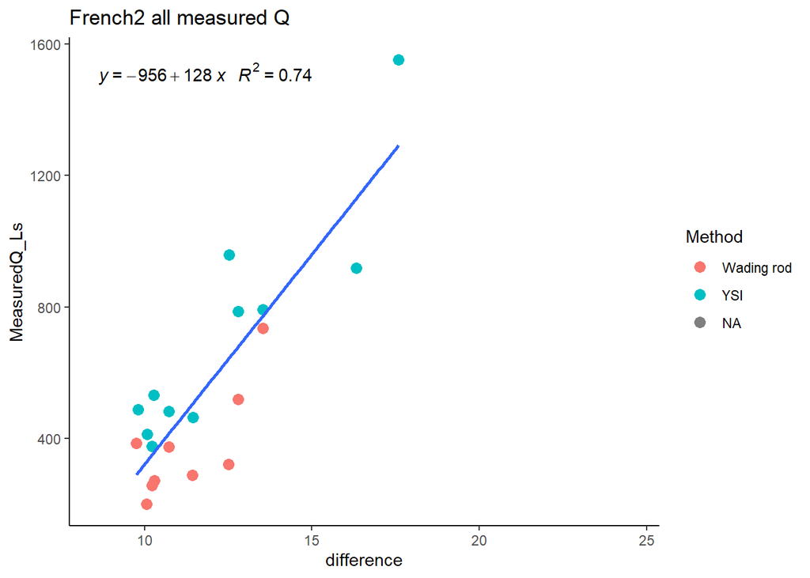

Lets try averaging the YSI and wading rod points.

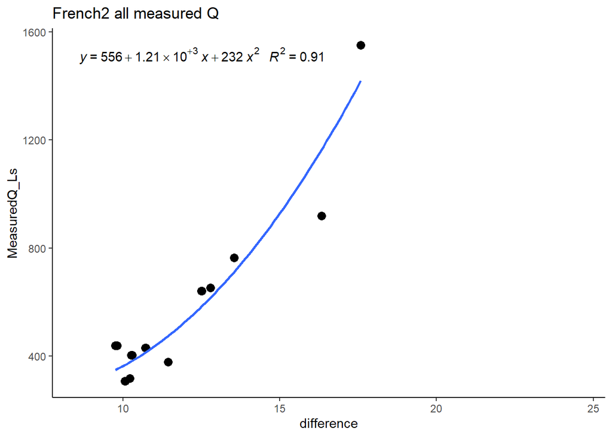

Maybe it is more accurate because it incorporates both the YSI and wading rod data.

## Final Q for FRCH PT2

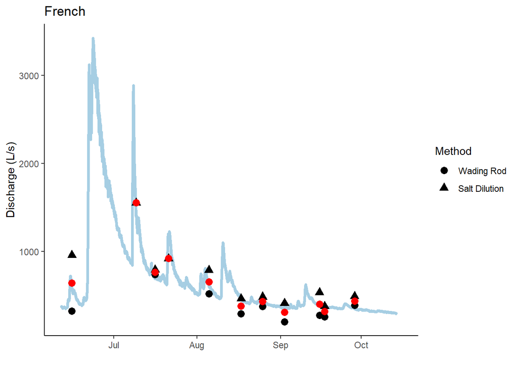

Looks pretty good.

## Export PT data to csv in DoD_Discharge->Predicted_Discharge->2020

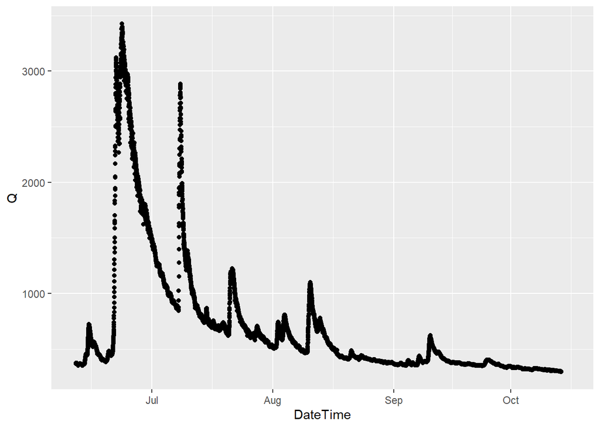

# Poker

## Raw Poker PT1

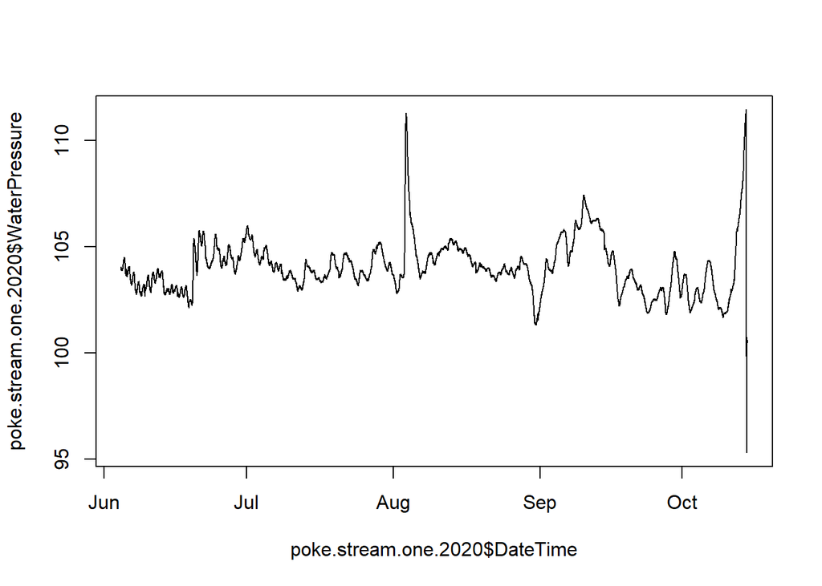

It looks like I need to remove out of water points at the end of the year and potentially shift middle of september-on up….let the cleaning commence!

Poker PT1 2.0

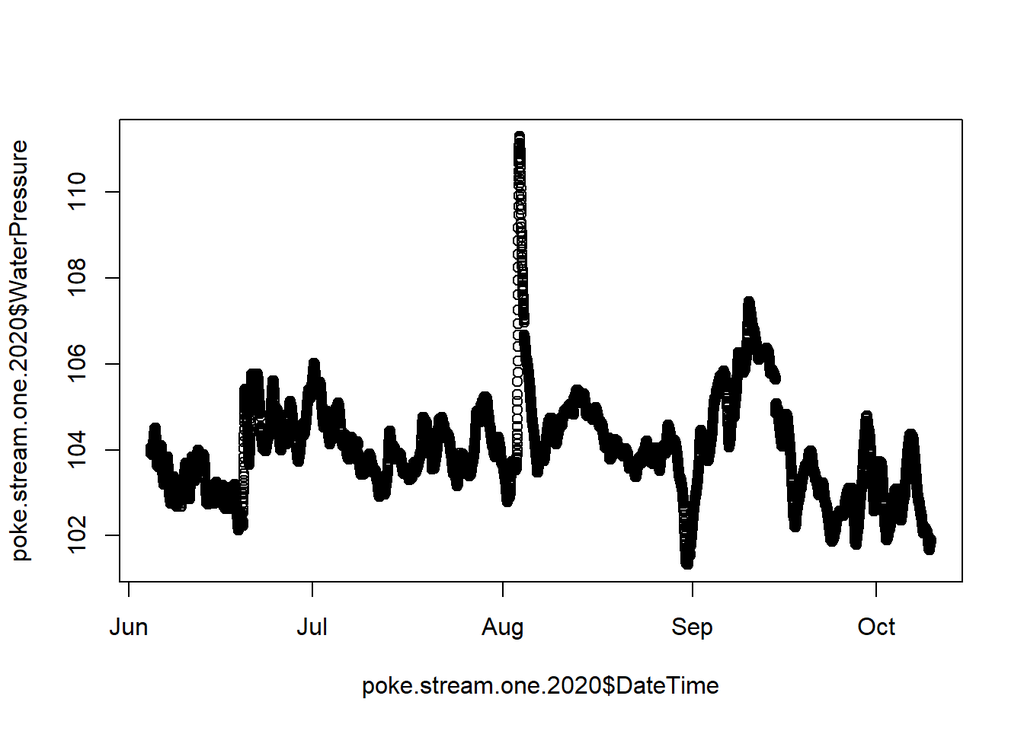